# Ayudantía III: Regresión Simple

SOL201S - Análisis Datos III

Luis Maldonado

Profesor Instituto de Sociología PUC  
lmaldona@uc.cl

Catalina Rufs

Estudiante Magíster en Sociología PUC  
cirufs@uc.cl

José Daniel Conejeros

Estudiante Magíster en Sociología PUC  
jdconejeros@uc.cl

01/09/2019

# **Objetivos**

- Introducir el método de Regresión Lineal Simple en el software estadístico `R`.
- Ejercitarse en la interpretación de los componentes de una Regresión Lineal Simple.

# **Contexto del ejercicio**

Usted tiene la hipótesis de que el puntaje obtenido en la PSU de matemáticas está determinado por el promedio de de notas obtenido en la enseñanza media (NEM). Concretamente usted cree que a mayor NEM de un estudiante, mayor es el puntaje obtenido en la PSU de matemáticas. Esta relación se puede formalizar de la siguiente manera:

$$PuntajeMate_{i} = \beta_{0} + \beta_{1}nem_{i} + \mu$$

- **Explique los componentes de la representación formal de un modelo de regresión simple**
- **¿Incide la posición de las variables dentro de una relación cuando se produce un análisis de regresión?**

# **Datos**

En esta oportunidad utilizaremos la base de datos `psu_sample` que es un extracto con información de 11762 estudiantes que rindieron la PSU para el año 2016. Las variables a utilizar son las siguientes:

- **Variable Dependiente**: Puntajes en la prueba de matemáticas (`mate`)
- **Variable Independiente**: Promedio de notas de enseñanza media (`x_nem`)

Además utilizaremos las funciones base de `R` y las librerías `dplyr` y `car`. Aplicamos las siguientes configuraciones inciales:

```r
##Configuraciones iniciales
rm(list = ls()) #Limpiamos la memoria
#install.packages("dplyr")#Para manipulación de datos
#install.packages("car")#Funciones para estimar regresiones
#install.packages("haven") #lectura/importar de bases de datos en stata

##Cargar librerías
library(dplyr)
library(car)
library(haven)
#search() #Revisamos los paquetes y herramientas instaladas
options(scipen=999) #Desactivamos la notación científica
```

# **Ejercicio**

**1. Desde el script: Carge los datos `psu_sample` y mantenga solamente las variables de interés**.

```r
#Importamos la base que está en formato dta
psu_sample <- read_dta("psu_sample.dta")
#Transformamos a un marco de datos
psu_sample <- as.data.frame(psu_sample)
#Seleccionamos las variables:
#V. Dependiente: Puntaje en la prueba de matemáticas (mate)
#V. Independiente: Promedio notas medias (x_nem)
psu_sample <- subset(psu_sample, select = c(mate,x_nem))
head(psu_sample)
```

```
##   mate x_nem
## 1  499    50
## 2  656    58
## 3  569    59
## 4  513    52
## 5  391    50
## 6  644    57
```

**2. Analice con estadística descriptiva univariada ambas variable. Solicite un histograma para cada variable y evalúe el tipo de distribución que tiene**

- Estadística descriptiva:

```r
summary(psu_sample$mate)
```

```
##    Min. 1st Qu.  Median    Mean 3rd Qu.    Max.
##     179     459     539     536     613     850
```

```r
sd(psu_sample$mate)
```

```
## [1] 110.2426
```

```r
summary(psu_sample$x_nem)
```

```
##    Min. 1st Qu.  Median    Mean 3rd Qu.    Max.
##   41.00   54.00   57.00   57.43   61.00   70.00
```

```r
sd(psu_sample$x_nem)
```

```
## [1] 4.936505
```

- Tabla de calidad

[figure not shown]

- Histogramas:

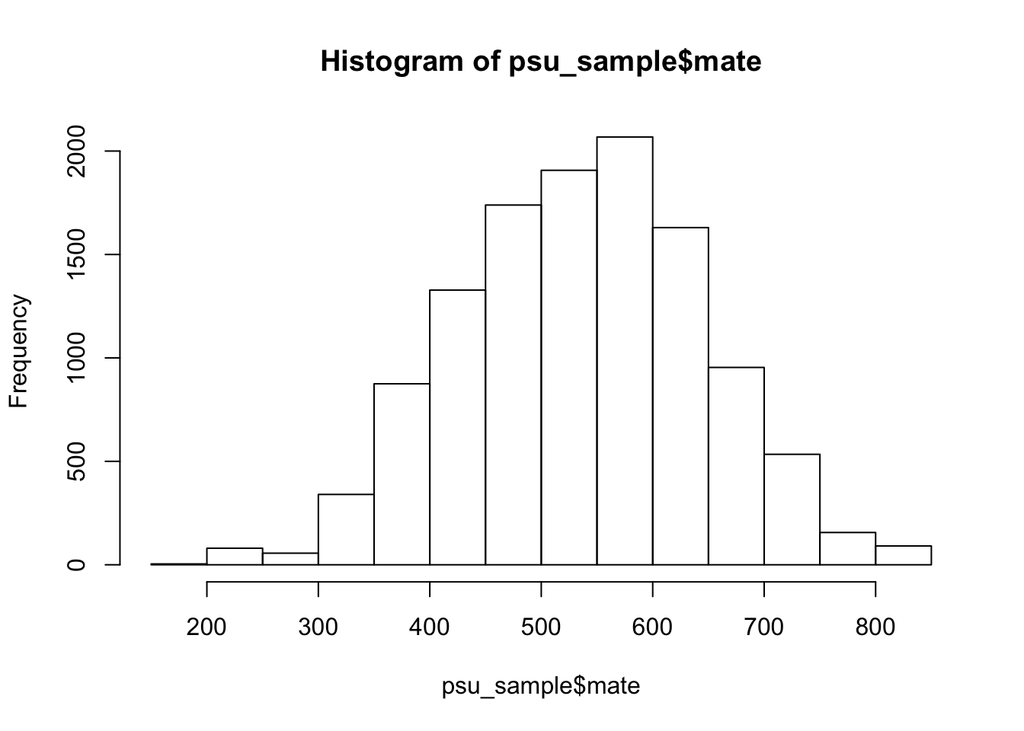

```r
#Histogramas sin especificaciones
hist(psu_sample$mate)
```

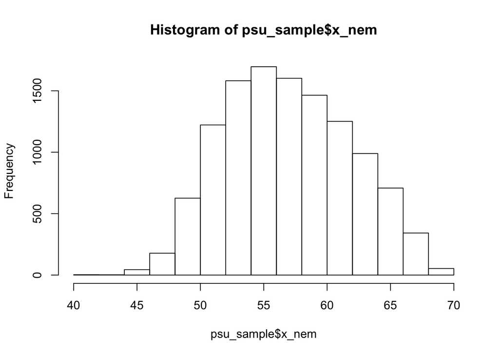

```r
hist(psu_sample$x_nem)
```

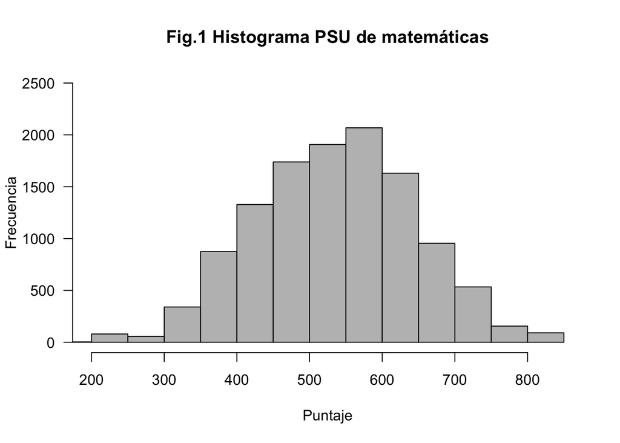

```r
#Figura de calidad
?hist #Revisamos las opciones de la función
hist(psu_sample$mate,
     main="Fig.1 Histograma PSU de matemáticas", #Nombre del histograma
     ylab = "Frecuencia", #Etiqueta el eje y
     xlab="Puntaje",      #Etiqueta el eje y
     border="black",      #Color del borde de cada barra
     col = "gray",        #Color al interior de cada barra
     xlim=c(200,850),     #Límites del eje x
     ylim=c(0,2500),      #Límites del eje y
     las=1,               #Orientación de los datos del eje x
     breaks=20)           #Quiebre de cada barra
```

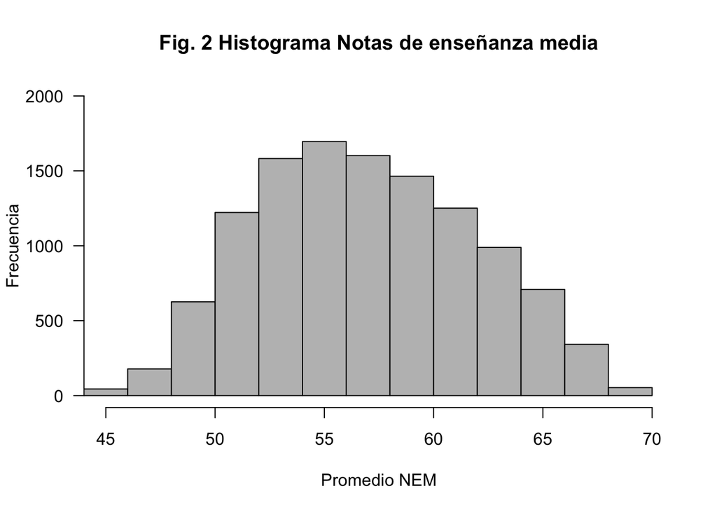

```r
hist(psu_sample$x_nem,
     main="Fig. 2 Histograma Notas de enseñanza media",
     ylab = "Frecuencia",
     xlab="Promedio NEM",
     border="black",
     col = "gray",
     xlim=c(45,70),
     ylim=c(0,2000),
     las=1,
     breaks=20)
```

**3. Formule los modelos de regresión simple teóricos y estimados para la hipótesis presentada. Describa también los modelos teóricos explicando a qué corresponde cada uno de sus componentes.**

- El modelo teórico:

$$PuntajeMate = \beta_{0} + \beta_{1}nem + \mu$$

- El modelo estimado:

$$\widehat{Puntaje Mate}= \widehat{\beta_{0}} + \widehat{\beta_{1}}nem$$

A estas ecuaciones se les llama **modelo de regresión lineal simple**, ya que relaciona solamente dos variables: la dependiente `Y` y la independiente `X` (podría ser multivariado e incorporar más de una variable independiente). La variable dependiente -puntaje de matemáticas obtenido en la PSU-, o también conocida como variable de respuesta o explicada, es aquella que como bien dice su nombre, queremos explicar a partir de las variables independientes del modelo. Estas últimas por otro lado, también conocidas como explicativas, son aquellas que buscan explicar la varianza de la variable dependiente respectiva.

Luego, tenemos tres términos adicionales: $\beta_{1}$, la constante $\beta_{0}$ y el error $\mu$. $\beta_{1}$ es el parámetro de la pendiente en la relación entre `Y` y `X` cuando todos los demás factores permanecen constantes, esto es, mide el efecto de la variable explicativa sobre la explicada ceteris paribus. Luego, la constante es el intercepto de la recta en el eje `Y`, es decir, el valor que toma nuestra variable dependiente cuando nuestra independiente toma el valor cero. Finalmente, el término error representa los factores distintos de `X` (variable independiente observada) que afectan a `Y`, es decir, representa todo lo no observado del modelo.

**4. Grafique la relación entre ambas variables. ¿Se observa una asociación?**

- Para graficar su relación:

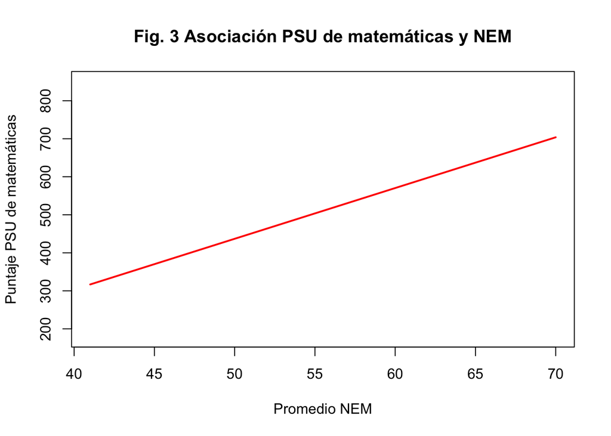

```r
#General
#?scatterplot #Consultamos la función
scatterplot(psu_sample$x_nem, psu_sample$mate,
            boxplots=FALSE, #quitamos boxplots
            regLine = list(col="red"), #agregamos una línea de asociación
            grid = FALSE, #sacamos el fondo cuadriculado
            smooth=FALSE, #limpiamos de otras estimaciones
            cex = 0,    #Tamaño relativo de cada estimación
            main = "Fig. 3 Asociación PSU de matemáticas y NEM",
            ylab = "Puntaje PSU de matemáticas",
            xlab = "Promedio NEM")
```

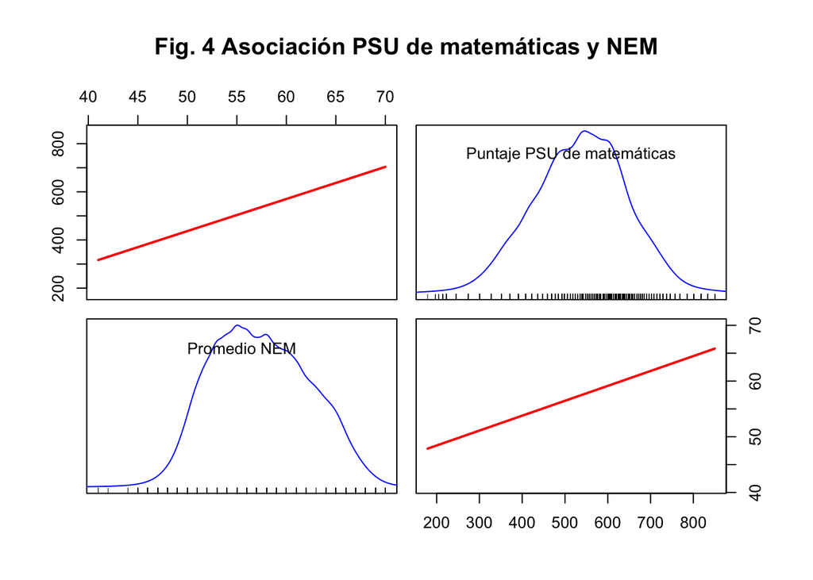

```r
#Matriz
#?scatterplotMatrix #Exploramos la función
scatterplotMatrix(~x_nem + mate, data=psu_sample,
                  regLine = list(col="red"), #agregamos una línea de asociación
                  plot.points = FALSE, #Sacamos cada uno de los valores
                  smooth=FALSE, #limpiamos de otras estimaciones,
                  var.labels=c("Promedio NEM", "Puntaje PSU de matemáticas"), cex.labels = 1,
                  main = "Fig. 4 Asociación PSU de matemáticas y NEM", row1attop = F)
```

**5. Calcule la correlación entre ambas variables. ¿Cuál es la intensidad y sentido de la asociación?**

```r
cor(psu_sample$mate, psu_sample$x_nem, method = "pearson")
```

```
## [1] 0.5976252
```

El coeficiente de correlación de Pearson mide la fuerza y dirección con que se relacionan linealmente dos variables continuas.